# Read a Graph

First we load the image and do a Hough transform that only looks for horizontal and vertical lines.

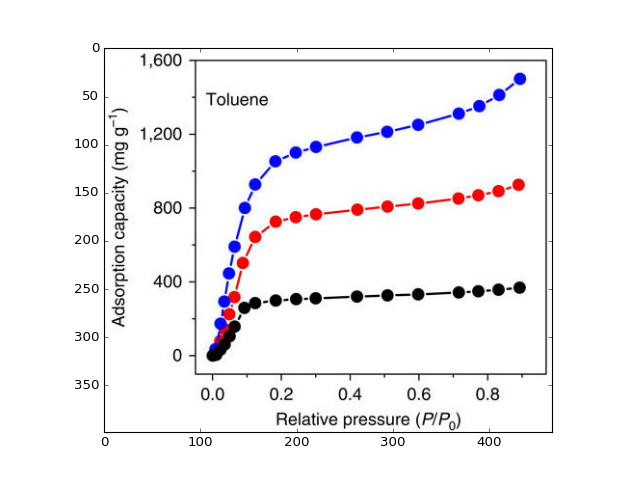

```python
import cv2
import numpy as np
import matplotlib.pyplot as plt
import IPython
import scipy.ndimage as ndimage
# try:
#     import Image
# except ImportError:
from PIL import Image
import pytesseract as tes

example = 'example101.jpg'
img = cv2.imread(example)
m,n,p=img.shape

gray = cv2.cvtColor(img,cv2.COLOR_BGR2GRAY)
blur = cv2.GaussianBlur(img,(3,3),0)
gray_blur = cv2.cvtColor(blur,cv2.COLOR_BGR2GRAY)
r,bw = th3 = cv2.threshold(gray,127,255,cv2.THRESH_BINARY)
ret2,bw2 = cv2.threshold(gray,0,255,cv2.THRESH_BINARY+cv2.THRESH_OTSU)
ret3,bw3 = cv2.threshold(gray_blur,0,255,cv2.THRESH_BINARY+cv2.THRESH_OTSU)
nbw = (255-bw3)

linesP = cv2.HoughLinesP(nbw,1,np.pi/2,2, minLineLength = nbw.shape[1]/10, maxLineGap = 3)[0]

%matplotlib notebook

implot = plt.imshow(img)
```

## Finding axes

Now we define the axis score, [cos^2, fractional length, fractional y-coord (or x coord for y axis)]

And we find the lines with the scores closest to these to be our x and y axes

```python
import find_axes
# print(linesP)
xax = find_axes.get_xaxis(linesP,nbw)
print(xax)
yax = find_axes.get_yaxis(linesP,nbw)
print(yax)
```

```
[ 94 339 458 339]
[ 94 337  94  15]
```

## Draw the axes

```python
imlabel = img.copy();
cv2.line(imlabel,(xax[0],xax[1]),(xax[2],xax[3]),(255,0,0),2)
cv2.line(imlabel,(yax[0],yax[1]),(yax[2],yax[3]),(255,0,0),2)
```

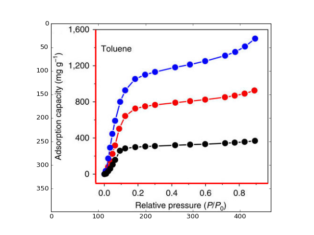

```python
%matplotlib notebook

implot = plt.imshow(imlabel)
implot.set_cmap('gray')
```

## OCR to find Tick Labels

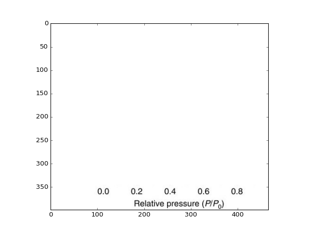

```python
%matplotlib notebook

# Find where the x-ticks stop and crop the text image to be below that
below_xax_bw = np.zeros([m,n]).astype('uint8')
below_xax_bw[xax[1]:,:]=nbw[xax[1]:,:]
row_sums = below_xax_bw.sum(axis=1)
row_sums[0:xax[1]] = 1000
row_sums_list = row_sums.tolist()
text_crop_ind = row_sums_list.index(0)
text_crop_ind

xTextImg = np.ones([m,n,p]).astype('uint8')*255
xTextImg[text_crop_ind+1:,:,:]=img[text_crop_ind+1:,:,:]

cv2.imwrite('xtext.png',xTextImg)
implot = plt.imshow(xTextImg)
```

```python
xocr = tes.image_to_string(Image.open('xtext.png'),boxes=True)
```

```python
import ocr_tools

words = ocr_tools.clean_ocr_results(xocr)
words
```

```
[['0.0', 101, 33, 125, 46],
 ['0.2', 172, 33, 196, 46],
 ['0.4', 244, 33, 267, 46],
 ['0.6', 315, 33, 339, 46],
 ['0.8', 386, 33, 410, 46],
 ['Relative', 179, 7, 242, 20],
 ['pressure', 249, 3, 317, 17],
 ['(P/PD)', 324, 2, 370, 20]]
```

```python
def is_number(s):
    try:
        float(s)
        return True
    except ValueError:
        return False

numbers = [w for w in words if is_number(w[0])]
for w in numbers:
    w[0]=float(w[0])
    w[2] = m-w[2]
    w[4] = m-w[4]
    w.append((w[1]+w[3])/2)
    w.append((w[2]+w[4])/2)

xt_labels = np.array(numbers)
xt_labels
```

```
array([[  0.00000000e+00,   1.01000000e+02,   3.66000000e+02,
          1.25000000e+02,   3.53000000e+02,   1.13000000e+02,
          3.59000000e+02],
       [  2.00000000e-01,   1.72000000e+02,   3.66000000e+02,
          1.96000000e+02,   3.53000000e+02,   1.84000000e+02,
          3.59000000e+02],
       [  4.00000000e-01,   2.44000000e+02,   3.66000000e+02,
          2.67000000e+02,   3.53000000e+02,   2.55000000e+02,
          3.59000000e+02],
       [  6.00000000e-01,   3.15000000e+02,   3.66000000e+02,
          3.39000000e+02,   3.53000000e+02,   3.27000000e+02,
          3.59000000e+02],
       [  8.00000000e-01,   3.86000000e+02,   3.66000000e+02,
          4.10000000e+02,   3.53000000e+02,   3.98000000e+02,
          3.59000000e+02]])
```

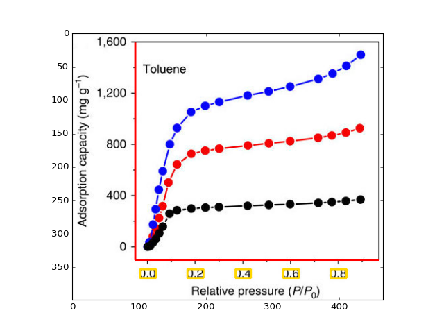

```python
%matplotlib notebook

for w in numbers:
    cv2.rectangle(imlabel, (w[1],w[2]), (w[3],w[4]), (255,215,0), thickness=2, lineType=8, shift=0)

implot = plt.imshow(imlabel)
```

## More Hough

We then sort the results by x-coordinate and remove duplicates that are adjacent to each other by less than 5 pixels.

Finally we accept as ticks vertical lines that are separated from one another by the median spacing of all of the lines.

```python
xt_dirty = find_axes.get_xticks(nbw,xax,tickMargin=11,minTickLen=0,maxGap=0)
xt_list=xt_dirty.tolist()
```

```python
xt_match = find_axes.match_xticks(numbers,xt_list)
xt_pts = [xt_list[i] for i in xt_match]
```

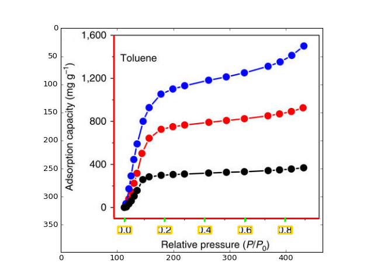

```python
%matplotlib notebook
for x1,y1,x2,y2 in xt_pts:
    cv2.line(imlabel,(x1,y1),(x2,y2),(0,255,0),2)

implot = plt.imshow(imlabel)
```

```python
xt_pts_array = np.array(xt_pts)
xt_pts_array[:,0].reshape(-1,1)
```

```
array([[113],
       [184],
       [255],
       [327],
       [398]])
```

```python
xt_labels[:,0].reshape(-1,1)
```

```
array([[ 0. ],
       [ 0.2],
       [ 0.4],
       [ 0.6],
       [ 0.8]])
```

## The moment you've all been waiting for...

### Regress the tick labels against the tick pixel positions to calibrate the x-axis

```python
from sklearn import datasets, linear_model
regrx = linear_model.LinearRegression(fit_intercept=True)

regrx.fit(xt_pts_array[:,0].reshape(-1,1), xt_labels[:,0].reshape(-1,1))

# The coefficients
print 'Coefficients: \n', regrx.coef_
print 'Intercept: \n', regrx.intercept_
```

```
Coefficients:
[[ 0.00280503]]
Intercept:
[-0.31640531]
```

## Now Get Y Ticks

```python
# Find where the y-ticks stop and crop the text image to be left of that
left_yax_bw = np.zeros([m,n]).astype('uint8')
left_yax_bw[:yax[0],:]=nbw[:yax[0],:]
col_sums = left_yax_bw.sum(axis=0)
col_sums[yax[0]:] = 1000
col_zeros=np.where(col_sums==0)[0]
y_crop_ind=col_zeros[-1]
```

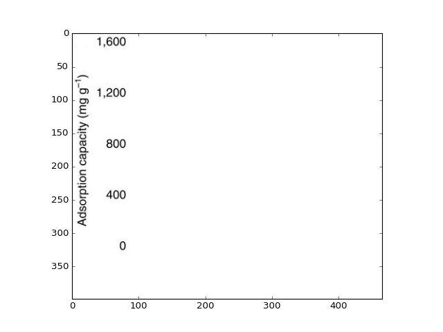

```python
%matplotlib notebook
yTextImg = np.ones([m,n,p]).astype('uint8')*255
yTextImg[:,0:y_crop_ind-1,:]=img[:,0:y_crop_ind-1,:]

cv2.imwrite('ytext.png',yTextImg)
implot = plt.imshow(yTextImg)
```

## Unfortunately

For OCR to work effectively on the y-axis, we must remove the rotated axis title completely. This is quite challenging.

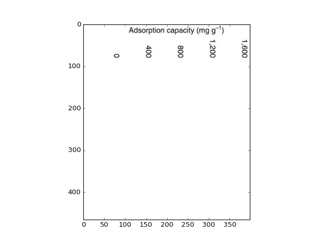

```python
%matplotlib notebook

yTextRot = ndimage.interpolation.rotate(yTextImg, -90)
cv2.imwrite('ytextrot.png',yTextRot)
implot = plt.imshow(yTextRot)
implot.set_cmap('gray')
```

```python
yRotOcr = tes.image_to_string(Image.open('ytextrot.png'),boxes=True)
```

### Find the longest "word" and clear its bounding box

```python
yrot_words = ocr_tools.clean_ocr_results(yRotOcr,charspace=10)
word_length = [len(i[0]) for i in yrot_words]
longest_word = np.array(word_length).argmax()
lwbox = yrot_words[longest_word]
lwbox
```

```
['Adsovplxoncapacity(mgg")', 109, 441, 335, 462]
```

```python
x1 = lwbox[1]-1
y1 = lwbox[2]-1
x2 = lwbox[3]+1
y2 = lwbox[4]+1
y1 = n-y1
y2 = n-y2
yTextRot[y2:y1+1,x1:x2+1,:] = np.ones([y1-y2+1,x2-x1+1,3]).astype('uint8')*255
yText_Clean = ndimage.interpolation.rotate(yTextRot, 90)
```

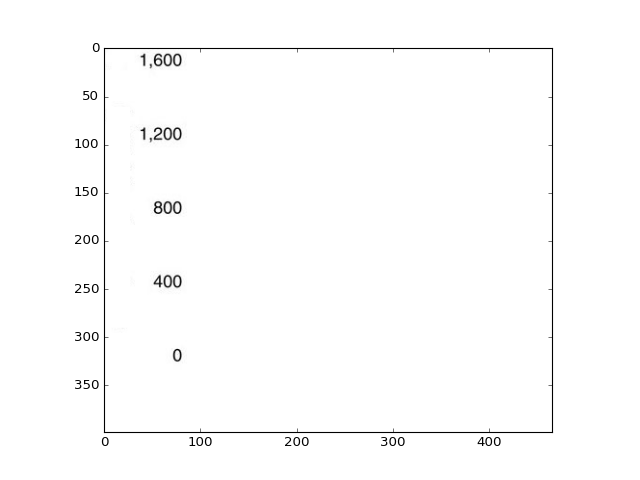

```python
%matplotlib notebook
implot = plt.imshow(yText_Clean)
```

### Now run conventional OCR

```python
cv2.imwrite('ytextclean.png',yText_Clean)
yocr = tes.image_to_string(Image.open('ytextclean.png'),boxes=True)
yl_ocr = ocr_tools.clean_ocr_results(yocr)
yl_ocr
```

```
[['1600', 38, 377, 81, 392],
 ['1200', 38, 300, 81, 316],
 ['800', 52, 226, 81, 239],
 ['400', 52, 150, 81, 163]]
```

```python
yt_numbers = [w for w in yl_ocr if is_number(w[0])]
for w in yt_numbers:
    w[0]=float(w[0])
    w[2] = m-w[2]
    w[4] = m-w[4]
    w.append((w[1]+w[3])/2)
    w.append((w[2]+w[4])/2)

yt_label_array = np.array(yt_numbers)
yt_label_array
```

```
array([[ 1600.,    38.,    22.,    81.,     7.,    59.,    14.],
       [ 1200.,    38.,    99.,    81.,    83.,    59.,    91.],
       [  800.,    52.,   173.,    81.,   160.,    66.,   166.],
       [  400.,    52.,   249.,    81.,   236.,    66.,   242.]])
```

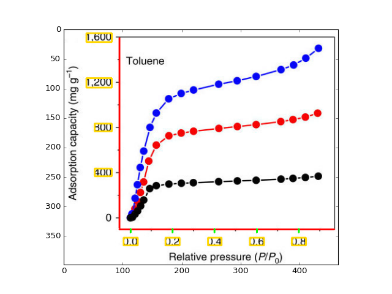

```python
%matplotlib notebook

for w in yt_numbers:
    cv2.rectangle(imlabel, (w[1],w[2]), (w[3],w[4]), (255,215,0), thickness=2, lineType=8, shift=0)

implot = plt.imshow(imlabel)
```

## Now run the same label/tick matching algorithm for the y-axis

```python
yt_dirty = find_axes.get_yticks(nbw,yax,tickMargin=11,minTickLen=0,maxGap=2)
yt_list=yt_dirty.tolist()
```

```python
yt_match = find_axes.match_xticks(yt_numbers,yt_list)
yt_pts = [yt_list[i] for i in yt_match]
yt_pts
```

```
[[89, 15, 104, 15], [88, 91, 95, 91], [89, 167, 95, 167], [88, 244, 95, 244]]
```

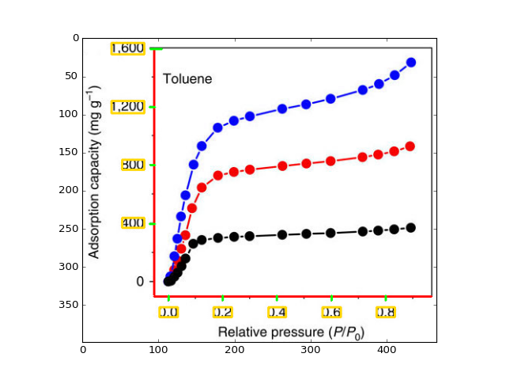

```python
%matplotlib notebook
for x1,y1,x2,y2 in yt_pts:
    cv2.line(imlabel,(x1,y1),(x2,y2),(0,255,0),2)

implot = plt.imshow(imlabel)
```

```python
yt_pts_array = np.array(yt_pts)
yt_pts_array[:,1].reshape(-1,1)
```

```
array([[ 15],
       [ 91],
       [167],
       [244]])
```

```python
yt_label_array[:,0].reshape(-1,1)
```

```
array([[ 1600.],
       [ 1200.],
       [  800.],
       [  400.]])
```

## Regress the y tick labels

```python
from sklearn import datasets, linear_model
regry = linear_model.LinearRegression(fit_intercept=True)

regry.fit(yt_pts_array[:,1].reshape(-1,1), yt_label_array[:,0].reshape(-1,1))

# The coefficients
print 'Coefficients: \n', regry.coef_
print 'Intercept: \n', regry.intercept_
```

```
Coefficients:
[[-5.24240993]]
Intercept:
[ 1677.58148323]
```

## Finally, Extract the Data

```python
from color_series_scrape import color_series_scrape

pix_pts, ROI = color_series_scrape(example, [[xax[0],xax[2]]],[[yax[3],yax[1]]], n_colors=4)
```

```
KM: fitting model on a small sub-sample of the data
done fitting
KM: Prediciting color indiced on the full image
done predicting
KM: recreating clustered image
```

```
KM: fitting model on a small sub-sample of the data
done fitting
KM: Prediciting color indiced on the full image
done predicting
KM: recreating clustered image
```

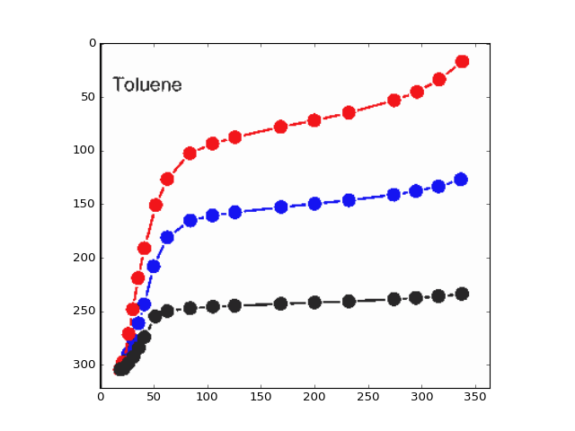

```python
from cluster_data import cluster_colorspace_km, return_series

im_recon, im_label = cluster_colorspace_km(ROI[0], 4)
labels_as_ims = return_series(im_label)

%matplotlib notebook
plt.imshow(im_recon)
```

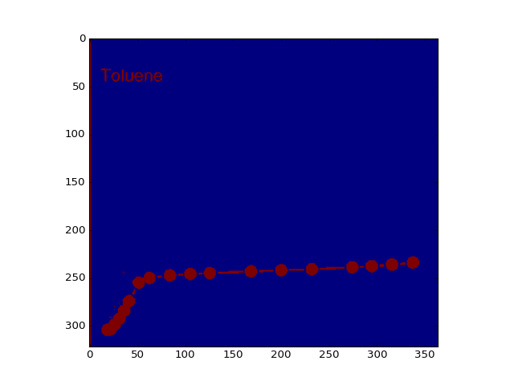

```python
%matplotlib notebook

plt.imshow(labels_as_ims[0])
```

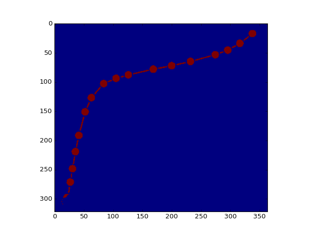

```python
%matplotlib notebook

plt.imshow(labels_as_ims[1])
```

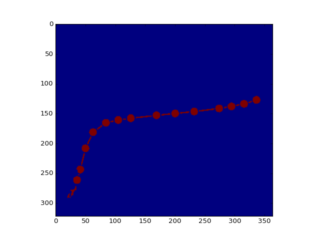

```python
%matplotlib notebook

plt.imshow(labels_as_ims[2])
```

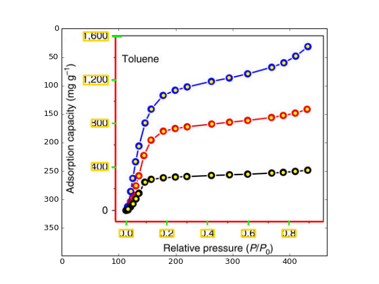

```python
%matplotlib notebook
imlabel4 = imlabel.copy()
pp_list = []
for series in pix_pts[0]:
    s_list = []
    for tup in series:
        x = int(round(tup[1]))+xax[0]
        y = int(round(tup[0]))+yax[3]
        s_list.append([x,y])
    pp_list.append(s_list)

pp_list

for series in pp_list:
    for pt in series:
        cv2.circle(imlabel4,(pt[0],pt[1]), 3, (255,240,10), -1)


lastplot = plt.imshow(imlabel4)
```

## ... and convert the pixel values to the units of the axes

```python
data_list = []
for series in pp_list:
    ser_list = []
    for pt in series:
        xdata = pt[0]*regrx.coef_+regrx.intercept_
        ydata = pt[1]*regry.coef_+regry.intercept_
        ser_list.append([xdata[0,0],ydata[0,0]])
    data_list.append(ser_list[::-1])

data_list
```

```
[[[0.0089784645889228187, 15.737535964271956],
  [0.034223757405993815, 62.919225318847339],
  [0.04824892008214432, 110.10091467342295],
  [0.059469050223064757, 157.28260402799833],
  [0.093129440645826067, 262.13080259372191],
  [0.12398479853335731, 288.34285223515258],
  [0.18289048177318956, 304.07008202001111],
  [0.24179616501302181, 309.31249194829729],
  [0.29789681571762405, 314.55490187658347],
  [0.41851321473251868, 325.03972173315583],
  [0.59803529698724567, 335.52454158972819],
  [0.50827425585988217, 330.28213166144201],
  [0.71584666346691017, 346.00936144630055],
  [0.77194731417151241, 351.25177137458672],
  [0.83085299741134466, 361.73659123115908],
  [0.89256371318640715, 372.22141108773144]],
 [[0.023003627265073379, 178.25224374114305],
  [0.031418724870763692, 298.82767209172493],
  [0.045443887546914252, 450.8575600120239],
  [0.06227408275829488, 592.4026280757505],
  [0.093129440645826067, 807.34143513548338],
  [0.12398479853335731, 933.15927341435145],
  [0.18289048177318956, 1058.9771116932195],
  [0.24179616501302181, 1106.1588010477949],
  [0.30070184825285418, 1137.613260617512],
  [0.41851321473251868, 1184.7949499720876],
  [0.50546922332465205, 1221.4918194700908],
  [0.59803529698724567, 1258.1886889680941],
  [0.71584666346691017, 1315.8551981792418],
  [0.77475234670674242, 1357.794477605531],
  [0.8336580299465749, 1420.7033967449652],
  [0.89256371318640715, 1509.82436552583]],
 [[0.04824892008214432, 230.67634302400484],
  [0.06227408275829488, 319.79731180486965],
  [0.087519375575365876, 508.52406922317186],
  [0.12117976599812719, 650.06913728689824],
  [0.18289048177318956, 728.70528621119092],
  [0.24179616501302181, 754.9173358526217],
  [0.30070184825285418, 770.64456563748024],
  [0.4213182472677488, 796.85661527891102],
  [0.50827425585988217, 812.58384506376956],
  [0.59803529698724567, 828.3110748486281],
  [0.71304163093168016, 854.52312449005888],
  [0.77194731417151241, 875.49276420320359],
  [0.83085299741134466, 896.46240391634831],
  [0.88975868065117691, 933.15927341435145]]]
```